# An R Markdown document converted from “Assignment-2024.ipynb”

# Omics in Oncology: Assignment + presentation

## Introduction

The study “Proteomics of Melanoma Response to Immunotherapy Reveals Mitochondrial Dependence” by Harel et al. (2019) uses mass spectrometry-based proteomics to analyze 116 melanoma tumors from patients undergoing either *tumor-infiltrating lymphocyte (TIL)*-based therapy (42 patients) or *anti-PD1 therapy* (74 patients). In this study, patients were classified as responders to immunotherapy (partial or complete response) or non-responders (progressive disease.  
Mass spectrometry analysis quantified over 10,300 proteins in patient biopsies, with statistical analyses performed on ~4,500 proteins per dataset. Differential protein expression was assessed using t-tests, volcano plots, heatmap clustering methods, and enrichment analyses to identify functional differences.  
Weighted gene correlation network analysis (WGCNA) was also applied to associate protein clusters with clinical outcomes to TIL or anti-PD1 therapy. From this analysis the authors made some conclusion about what mechanisms are driving immunotherapy resistance in patients. For example, patients who responded to treatment had higher oxidative phosphorylation and lipid metabolism signatures in their proteome data. These signatures were associated with increased antigen presentation and IFN signaling.  
From their analysis, the authors concluded that mitochondrial metabolism plays a crucial role in shaping tumor immunogenicity and response to immunotherapy.

What else can we learn from this interesting proteomics dataset? For your final assessment, it is time for you to apply your data analysis skills to dig deeper into the data and see what biological inferences can be made to understand how patients respond to immunotherapy at a molecular level. Check out the Harel et al. 2019 publication for inspiration in your data analysis.

## Overview

For this assignment we want you to:

1. Load in the data from the cell paper CELL-179 supplementery data 1. We focus on the anti-PD1 data of this experiment.
   - The ExpSetup data is in the *S1A* sheet
   - The PD data is in the S1D sheet
2. Perform a **T-test** on the PD data to get the most significantly changed proteins between Responders and Non responders.
3. Create a **volcano plot** and label the top 10 proteins and color the significant up/down regulated proteins.
4. Create a **heat map** of the top 10 most significantly changing proteins to see if there are any patterns
5. With the t-test and volcano plot you can start the network and enrichment analysis
   - Get the 1000 most significant proteins from our test
   - Find which proteins are interaction according to the **String database** and export this network/graph
   - Extract communities from the network using the igraph package. The result will contain 3 big clusters that we’re interested in and some clusters with just a few proteins.
6. Based on your group number you have to investigate cluster 1, 2 or 3 further. We will perform an enrichment analysis on your (sub) cluster

## R libraries

# Reading in the files

This part of the code you get for free, to make sure, everyone has the correct data. The Excel file downloaded from the Cell journal website has different sheets for the supplementary tables. Here we will read the correct sheets. Also they have added a line above each sheet with some minor info, that we will need to skip.

```r
## The experimental setup (which tells which patient is a responder and who is not) in Sheet S1A
## First, we'll read it into the ExpSetup variable
ExpSetup <- read_xlsx("CELL-179-suppl1.xlsx", sheet="S1A", na="NaN", skip = 1)

# Rename a few columns
ExpSetup %<>% rename(Sample="Sample ID", Age = "Age at treatment")

# remove some non essential columns
ExpSetup %<>% select(-c("Nb of CD8 cells in infusion bag (x10^10)", "Sample taken after treatment"))

# The authors were sloppy and sometimes forgot an underscore in the Sample names. Not handy as this causes issues in combining the data later on.
ExpSetup %<>% mutate(Sample = str_replace(Sample, " ", "_"))

## Sheet S1D contains the actual quantitative data
## We'll read it into the PDdata variable
PDdata_raw <- read_xlsx("CELL-179-suppl1.xlsx", sheet="S1D", na="NaN", skip = 1)
```

## Inspecting the imported data

Make sure the data is correct by having a look at the table

```r
## You: Output ExpSetup, to check if all the steps above have worked

head(ExpSetup)
```

```
## # A tibble: 6 × 11
##   Sample Cohort gender   Age `BRAF mutation` `LDH above normal?` Response
##   <chr>  <chr>  <chr>  <dbl> <chr>           <chr>               <chr>
## 1 TIL_6  TIL    F         49 N               N                   CR
## 2 TIL_16 TIL    M         66 N               N                   CR
## 3 TIL_1  TIL    M         61 Y               N                   CR
## 4 TIL_44 TIL    M         59 Y               N                   CR
## 5 TIL_35 TIL    F         53 N               N                   PD
## 6 TIL_2  TIL    F         43 Y               N                   PD
## # ℹ 4 more variables: `PFS time (months)` <dbl>, `OS time (months)` <dbl>,
## #   `prior targeted therapy` <chr>, `Prior Ipilimumab` <chr>
```

You need to still check if the name of your PD dataset (below it is called PDdata) is the same as yours. If not you need to change either your variable name, or the code below so that these match.

Also this step you get for free: We combine the ExpSetup with the quantitative data.

```r
# The names are a bit confusing, let's first fix that
PDdata_raw %<>%
    rename(Gene_name = "T: T: Gene name",
           Ensembl_accession = "T: ENSP",
           Protein_name = "T: Protein name",
           Uniprot_accession = "T: Uniprot")

# Because sometimes we have multiple names for the gene names and accessions,
# we are only going to look at the first ones.
# We use the 'purrr' library to be able to use map_chr.
# This is a bit more advanced code as well, so don't worry about it.
# the result is that the columns with multiple values only show the first value from now on.

PDdata_raw %<>%
    mutate(Gene_name = map_chr(Gene_name, ~{ str_split_i(.x, ";", 1)} ),
           Ensembl_accession = map_chr(Ensembl_accession, ~{ str_split_i(.x, ";", 1)} ),
           Uniprot_accession = map_chr(Uniprot_accession, ~{ str_split_i(.x, ";", 1)} ),
           Protein_name = map_chr(Protein_name, ~{ str_split_i(.x, ";", 1)} ))

# Here we take all the column titles that start with "PD", and use them as a
# variable (column) called "Sample"
# The numbers in these columns is stored in a column called "Expression"
# All remaining columns still exist and the values are duplicated as needed so they
# still correspond to the correct expression values

PDdata <- PDdata_raw %>%
    pivot_longer(starts_with("PD"), names_to = "Sample", values_to = "Expression") %>%
    relocate(c(Sample, Expression))

## the data from the ExpSetup table is combined with the PDdata table, based on
## where the Sample column values are the same between them
PDdata %<>% left_join(ExpSetup, by="Sample")

## The 'response' variable now has three levels: PR, CR are responders, PD are non-responders
## we're going to convert the Response into, with values NR (no respones) or R (response) based on this information

PDdata %<>% mutate(Response = ifelse(Response=='PD', "NR", "R"))
```

## Plot a histogram of one protein

Take the data, and use ‘filter’ to extract a single protein **PSME1**. Use ggplot to create a histogram. Of the histogram bars, make ‘fill’ of the histogram from the Response variable. Discuss what you observe in this plot.

# Statistical analysis

## Perform t-tests

We have now given you an idea of how a single protein expression behaves between two situations, but now let’s get a bit more systematic. We’ll do a statistical test to see if protein expression is different between non-responders and the responders.

The following code does the following things:

- group all genes, and for each gene calculate a t-test of expression vs response and store the p-value
- calculate the fold change, which is the difference between the median expression of response / no response
- remove the original data
- sort the table according to the p-value (low -> high)
- perform an operation so that the fold_change is centered around 0, by subtracting the median of all fold_changes

The results are stored in a table t_tests

```r
# for readability, this is a function to calculate the fold_change column for each protein
fold_change <- function(gene_table) {
  medians <- tapply(gene_table$Expression, gene_table$Response, median, na.rm=TRUE)
  # The data is already in log2 scale, so the values are simply subtracted
  return( medians["R"] - medians["NR"] )
}

t_tests <- PDdata %>%
  group_by(Gene_name) %>%
  nest() %>%
  mutate(p_value = map_dbl(data, function(x) { return (t.test(x$Expression ~ x$Response)$p.value)})) %>%
  mutate(fold_change = map_dbl(data, fold_change)) %>%
  select(-data) %>%
  arrange(p_value) %>%
  ungroup() %>%
  mutate(fold_change = fold_change - median(fold_change))
```

### Inspect the contents of the t_tests table

use the ‘head’ function to show the **10** proteins with the lowest p-values. As you can see PSME1 is indeed upregulated (fold_change>0).

```r
head(t_tests %>% select(Gene_name, p_value, fold_change), 10)
```

```
## # A tibble: 10 × 3
##    Gene_name     p_value fold_change
##    <chr>           <dbl>       <dbl>
##  1 PSME1     0.000000366       0.873
##  2 B2M       0.00000147        1.10
##  3 TAPBP     0.00000275        1.23
##  4 PTK7      0.00000701       -1.01
##  5 TAP2      0.00000919        1.65
##  6 NXN       0.0000111        -1.12
##  7 STAT1     0.0000267         0.924
##  8 LAP3      0.0000293         0.654
##  9 PSMB5     0.0000434        -0.929
## 10 TAP1      0.0000440         1.06
```

### Check histograms to see if the fold_change makes sense

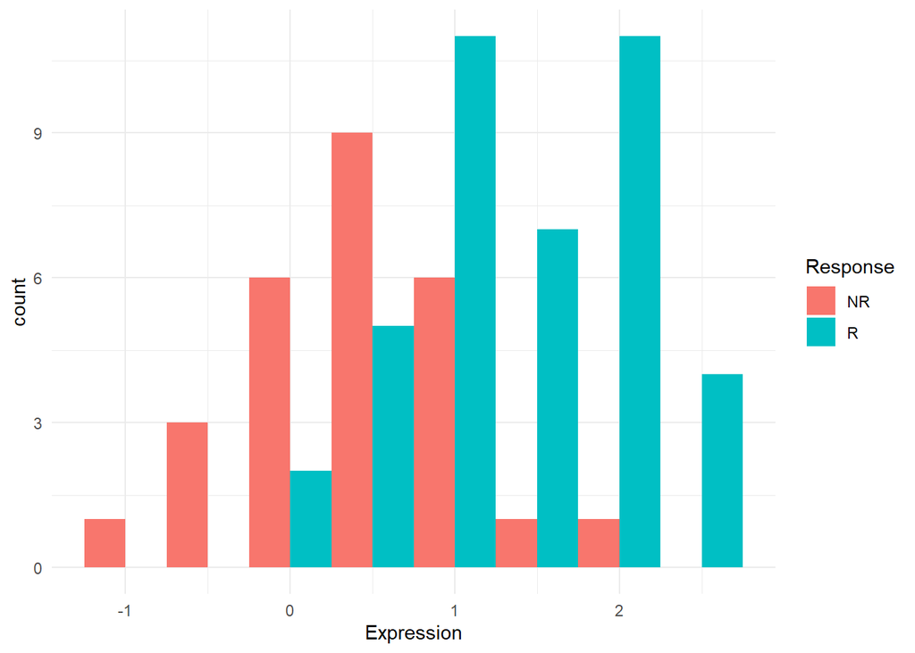

```r
PDdata %>%
  filter(Gene_name == "PSME1") %>%
  ggplot(aes(x=Expression, fill = Response)) + geom_histogram(binwidth = 0.5, position = "dodge")+theme_minimal()
```

## Creating a volcano plot

We want to create a volcano plot, so we will need a fold change. In this case we’ll calculate that based on the median Expression value for every gene.

This part of the code, you again get for free… Make sure you have all the variables needed to run this code:

- We define significance ‘up’ vs ‘down’ or non-significant ‘ns’
- The limits for these are, p-value <= 0.05, and the fold change

```r
# Create new column with 'up', 'down'
diseased_vs_healthy <- t_tests %>%
  mutate(significance = case_when((fold_change >= 0.3 & p_value <= 0.05) ~ "up",
                               (fold_change <= -0.3 & p_value <= 0.05) ~ "down",
                               TRUE ~ "ns"))

head(diseased_vs_healthy)
```

```
## # A tibble: 6 × 4
##   Gene_name     p_value fold_change significance
##   <chr>           <dbl>       <dbl> <chr>
## 1 PSME1     0.000000366       0.873 up
## 2 B2M       0.00000147        1.10  up
## 3 TAPBP     0.00000275        1.23  up
## 4 PTK7      0.00000701       -1.01  down
## 5 TAP2      0.00000919        1.65  up
## 6 NXN       0.0000111        -1.12  down
```

```r
# Obtain significance counts
diseased_vs_healthy %>%
  count(significance)
```

```
## # A tibble: 3 × 2
##   significance     n
##   <chr>        <int>
## 1 down           102
## 2 ns            4195
## 3 up             323
```

The following code is given, make sure you understand what everything means!

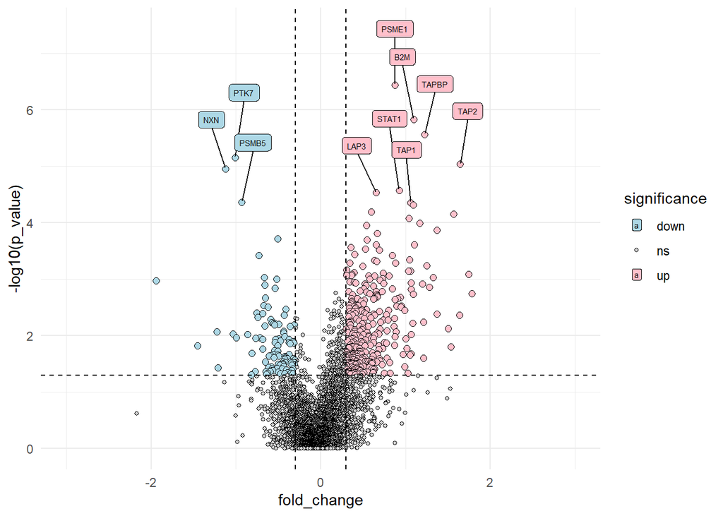

```r
## This line finds the top 50 significant names of the proteins (change this number to see more or less labels)
sig_il_genes <- diseased_vs_healthy %>% filter(significance != "ns") %>% slice(1:10)

# Let's prepare some colors and sizes that we will use in the plot

cols <- c("up" = "pink", "down" = "lightblue", "ns" = "lightgrey")
sizes <- c("up" = 2, "down" = 2, "ns" = 1)

diseased_vs_healthy %>%
  ggplot(aes(x = fold_change,
             y = -log10(p_value),
             fill = significance,
             size = significance)) +
  geom_point(shape = 21) +
  geom_hline(yintercept = -log10(0.05),
             linetype = "dashed") +
  geom_vline(xintercept = c(-0.3, 0.3),
             linetype = "dashed") +
  scale_fill_manual(values = cols) + # Modify point colour
  scale_size_manual(values = sizes) + # Modify point size
  geom_label_repel(data = sig_il_genes, # Add labels last to appear as the top layer
                   aes(label = Gene_name),
                   force = 2,
                   nudge_y = 1) +
  scale_x_continuous(limits=c(-3,3)) +
  theme_minimal()
```

## Create a heatmap

Create an `annotation_tile` based on the Response for each each patient sample.

# Network analysis

We’re going to try to find some biological meaning in our data. For that we’ll use the String database, that has been presented before.

We’ll do a network query with significant proteins from the t_tests table that you created also for the volcano plot. We’ll take the top 1000 most significantly changed proteins and upload those to the String database. We’ll then get a network with the existing interactions, that we can analyze to extract protein networks from the huge fuzz ball.

### Create the list with proteins

First you will need to get the top-1000 protein names from the list of significant proteins. Use the R `write` function to create a text file with just the names of the proteins. The dplyr `pull` and `slice` functions can be helpful here.

```r
protein_list <- t_tests %>%
  slice(1:1000) %>%
  select(Gene_name, fold_change)
write_tsv(protein_list, "protein_list_STRINGdb.txt", col_names = FALSE)
```

### Export the network from string-db.org

Below the network (hairball), select the Exports tab. Export as a short tabular text output, but also as a graphical file for the presentation. Place this file in your project folder, and read it in. Find the correct columns to use in the graph that we’re going to use.

Create the protein graph from the imported table, using the function `graph_from_data_frame` from the igraph package (already loaded). When you have created the graph, it’s necessary to also use the `simplify` function on it to make the data less complex.

```r
string_network <- read_delim("string_interactions.tsv", delim="\t")
print(string_network)
```

```
## # A tibble: 22,808 × 13
##    `#node1` node2    node1_string_id      node2_string_id neighborhood_on_chro…¹
##    <chr>    <chr>    <chr>                <chr>                            <dbl>
##  1 A2M      NFKB1    9606.ENSP00000323929 9606.ENSP00000…                      0
##  2 A2M      CTSD     9606.ENSP00000323929 9606.ENSP00000…                      0
##  3 A2M      LRP1     9606.ENSP00000323929 9606.ENSP00000…                      0
##  4 A2M      GDF15    9606.ENSP00000323929 9606.ENSP00000…                      0
##  5 A2M      PDGFRB   9606.ENSP00000323929 9606.ENSP00000…                      0
##  6 A2M      C4BPA    9606.ENSP00000323929 9606.ENSP00000…                      0
##  7 A2M      ISG15    9606.ENSP00000323929 9606.ENSP00000…                      0
##  8 A2M      ALDOA    9606.ENSP00000323929 9606.ENSP00000…                      0
##  9 A2M      SERPINB1 9606.ENSP00000323929 9606.ENSP00000…                      0
## 10 A2M      APOD     9606.ENSP00000323929 9606.ENSP00000…                      0
## # ℹ 22,798 more rows
## # ℹ abbreviated name: ¹neighborhood_on_chromosome
## # ℹ 8 more variables: gene_fusion <dbl>, phylogenetic_cooccurrence <dbl>,
## #   homology <dbl>, coexpression <dbl>,
## #   experimentally_determined_interaction <dbl>, database_annotated <dbl>,
## #   automated_textmining <dbl>, combined_score <dbl>
```

```r
proteingraph <- graph_from_data_frame(string_network, directed = FALSE)
proteingraph <- simplify(proteingraph)
```

The following code will extract the networks from your protein graph (given). You can also see a graphical representation of the clusters.

[figure not shown]

```r
clusterList <- cluster_fast_greedy(proteingraph)

plot(clusterList, proteingraph)
```

### Extract the lists from the clusters

In order to get the clusters, you will need to extract them from the clusterList, you can use the `communities` function.

```r
clusters <- communities(clusterList)
write.table(clusters[[3]], file = "Grp6_clusterIDsFromCluster3.txt", quote = FALSE, row.names = FALSE)
```

We’re going to focus on the 3 largest clusters. Each group is working on a subset.

- Group 1: Will work with cluster 1 (clusters[[1]])
- Group 2: Will work with cluster 2 (clusters[[2]])
- Group 3: Will work with cluster 3 (clusters[[3]])
- Group 4: Will work with cluster 1 (clusters[[1]])
- Group 5: Will work with cluster 2 (clusters[[2]])
- Group 6: Will work with cluster 3 (clusters[[3]])
- …
- Use your clusters for further sub-clustering and subsequent enrichment analysis of the subclusters.
- Try to identify which functions, kinds of proteins, cellular localization, enzymatic activities are enriched.
- Put these enrichment in context of cancer. Did you find hallmarks? Important protein complexes/functions that play a role in cancer? And discuss this in your presentation.

# Prepare a Presentation

- Make a powerpoint presentation of 10-15 minutes.
- Explain the steps you have performed, but don’t use R code. Explain it in simple steps.
- Show your heatmap(s) and volcano plots, and provide some insights.
- Show the results of your String clusters, subclusters and the main outcome(s) of your enrichment analysis
- Explain the results of your enrichment in context of cancer. What do you finding suggest, or point at? Can you explain the roles of the proteins etc.